# Case Study 4 - ARIMA: Stock Prices

Yao Yao, Ivelin Angelov, Brian Kruse

MSDS 7333 Section 402

June 4, 2018

## Introduction

Historical time series data in the form of financial stocks could be analyzed by Python's statistical libraries and modules to study and model market trends [1]. This case study demonstrates Python's effectiveness to pull 4 years of a given stock data, test for stationarity after subtracting for price shift, plot for convergence based on partial and autocorrelation functions, use grid search to find the optimal ARIMA parameters while minimizing for root sum square, and compare the results of the ARIMA parameters based on convergence plots and that of grid search. The final decision for the best ARIMA parameters to fit the stock model is dependent on Occam's razor, where the simpler model that uses less assumptions is the optimal model because it is less likely to over-fit the data [2].

The objective of this notebook is to show a working example of Python libraries and modules for ARIMA stock analysis guided with methods, results, and conclusions.

### Import the Referenced Libraries and Change Settings:

```python
import sys
try:
    sys.getwindowsversion()
except AttributeError:
    isWindows = False
else:
    isWindows = True
if isWindows:
    import win32api,win32process,win32con
    pid = win32api.GetCurrentProcessId()
    handle = win32api.OpenProcess(win32con.PROCESS_ALL_ACCESS, True, pid)
    win32process.SetPriorityClass(handle, win32process.HIGH_PRIORITY_CLASS)
import warnings
warnings.filterwarnings('ignore')
import pandas as pd
import numpy as np
from pandas import read_csv
from pandas import datetime
from matplotlib import pyplot as plt
import matplotlib
from statsmodels.tsa.arima_model import ARIMA
from statsmodels.tsa.stattools import adfuller
from statsmodels.tsa.stattools import acf, pacf
import statsmodels.api as sm
pd.core.common.is_list_like = pd.api.types.is_list_like
from pandas_datareader import data as web
import datetime
%matplotlib inline
```

## Methods

ARIMA is a forecasting model made up of autoregressive, integrated, and moving average for univariate time series application [3]. Autoregressive (p) is the number to which the data correlates with itself after a number of lagged observations. Integrated (d) is the number of non-seasonal differences needed for the time series to be stationary. Moving average (q) is the number of lagged forecast errors in the prediction model. Accuracy of the model's variables can help predict future trends but does not compensate for outside intervention [3].

To use the ARIMA model, the data has to be stationary, where there are no trends or seasonality [3]. In order to create stationary data from stock prices, the differences in the shift of stock prices are calculated for the resulting data to be relatively horizontal with no trends or seasonality, as shown by the rolling mean and rolling standard deviation.

To find a stable stock with low variance for our stationary model, we chose General Mills (NYSE:GIS) because they have a myriad of staple breakfast brands and various food products, where consumers would have a relatively inelastic demand for basic human needs and standard diet regardless of market change over a 4-year period [4].

Our Python procedure is modified from code examples found in an online ARIMA time series tutorial as well as that from class lecture [5, 6]:

1. Pull and plot 4 years of General Mills (GIS) stock data
2. Test for stationarity before and after subtracting for price shift while plotting for rolling mean and rolling standard deviation
3. Plot for convergence based on partial and autocorrelation functions and manually find the ARIMA parameters
4. Use grid search to find the optimal ARIMA parameters while minimizing for root sum square
5. Compare the results of the ARIMA parameters based on convergence plots and that of grid search
6. Evaluate and decide for the best ARIMA parameters

## Results

### Load and Plot the 4-Year General Mills Stock Price

Using the web.DataReader function, we obtain the General Mills (GIS) stock closing prices indexed from 1/1/2014 to 2/1/2018, where Figure 1 shows the plotted time series for the stock prices within that 4-year period.

```python
start = datetime.datetime(2014, 1, 1)
end = datetime.datetime(2018, 2, 1)
price = web.DataReader('GIS', 'iex', start, end)['close']
price.index = pd.to_datetime(price.index)
```

```
5y
```

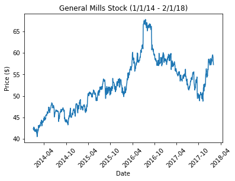

```
Figure 1: General Mills Stock Prices from 1/1/14 to 2/1/18
```

```python
fig = plt.figure()
plt.plot(price)
plt.title('General Mills Stock (1/1/14 - 2/1/18)')
plt.xlabel('Date')
plt.xticks(rotation='45')
plt.ylabel('Price ($)')
plt.show();
print("Figure 1: General Mills Stock Prices from 1/1/14 to 2/1/18")
```

### Function that Implements the Dickey-Fuller Test and Plots Data Along With Rolling Mean and Standard Deviation

This function plots the rolling mean and standard deviation along the data and tests for stationarity based on the Dickey-Fuller test. A p value above 0.05 suggests that the data is not stationary and that there are significant trends in the time series while a p value under 0.05 suggests that of the opposite. It also calculates for number of lags, if any, and the critical values.

```python
def test_stationarity(timeseries):

    #Determing rolling statistics
    rolmean = timeseries.rolling(12).mean()
    rolstd = timeseries.rolling(12).std()

    #Plot rolling statistics:
    fig = plt.figure()
    orig = plt.plot(timeseries, color='blue',label='Original')
    mean = plt.plot(rolmean, color='red', label='Rolling Mean')
    std = plt.plot(rolstd, color='black', label = 'Rolling Std')
    plt.legend(loc='best')
    plt.title('Rolling Mean & Standard Deviation')
    plt.xlabel('Date')
    plt.xticks(rotation='45')
    plt.ylabel('Price ($)')
    plt.show();

    plt.show(block=False)

    #Perform Dickey-Fuller test:
    print('Results of Dickey-Fuller Test:')
    dftest = adfuller(timeseries, autolag='AIC')
    dfoutput = pd.Series(dftest[0:4], index=['Test Statistic','p-value','#Lags Used','Number of Observations Used'])
    for key,value in dftest[4].items():
        dfoutput['Critical Value (%s)'%key] = value
    print(dfoutput)
```

### Test for Stationarity

The original time series of the stock without any changes suggest that the data is not stationary because the p value is above 0.05 [Figure 2].

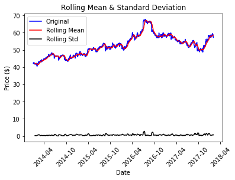

```
Results of Dickey-Fuller Test:
Test Statistic                   -1.882037
p-value                           0.340558
#Lags Used                        0.000000
Number of Observations Used    1028.000000
Critical Value (1%)              -3.436727
Critical Value (5%)              -2.864356
Critical Value (10%)             -2.568269
dtype: float64
Figure 2: Testing for stationarity while plotting for rolling mean and rolling standard deviation
```

```python
test_stationarity(price)
print("Figure 2: Testing for stationarity while plotting for rolling mean and rolling standard deviation")
```

### Test for Stationarity after a Subtracting for Price Shift

Therefore, a shift in price difference is used to test for stationarity, where the test statistic of -32.85 suggests a p value of less than 0.000001, which passes the test for further ARIMA analysis [Figure 3]. Note that the shift in price difference does not affect critical values while keeping the data integrity of the original dataset.

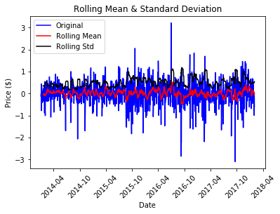

```
Results of Dickey-Fuller Test:
Test Statistic                  -32.853688
p-value                           0.000000
#Lags Used                        0.000000
Number of Observations Used    1027.000000
Critical Value (1%)              -3.436733
Critical Value (5%)              -2.864358
Critical Value (10%)             -2.568271
dtype: float64
Figure 3: Testing for stationarity after subtracting for price shift while plotting for rolling mean and rolling standard deviation
```

```python
diff=price-price.shift()
diff.dropna(inplace=True)
test_stationarity(diff)
print("Figure 3: Testing for stationarity after subtracting for price shift while plotting for rolling mean and rolling standard deviation")
```

### Plot Autocorrelation and Partial Autocorrelation Functions to Find Convergence

The plotting of the autocorrelation function (ACF) and partial autocorrelation function (PACF) is a manual method to find p and q values for the ARIMA model. Figure 4 shows that q = 1 because it is the lag value where the ACF plot crosses the upper confidence interval for the first time [5]. Figure 5 shows that p = 1 because it is the lag value where the PACF plot crosses the upper confidence interval for the first time [5]. For both Autoregressive and Moving Average models, the ACF and PACF shows an exponential dampening and a converge towards 0 at the first order value for both p and q [7]. Therefore, the plotting of ACF and PACF suggest an ARIMA model of (1, 0, 1), where p = 1, d = 0, q = 1. The differencing value is 0 because the original data had to be initially shifted to create a stationary graph to pass the Dickey-Fuller test.

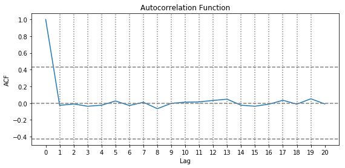

```
Figure 4: Plotting for Autocorrelation shows that it converges to 0 at lag = 1
```

```python
acf_stock_plot = acf(diff, nlags=20)
#Plot ACF:
plt.figure(figsize=(20, 4))

plt.subplot(121)
plt.plot(acf_stock_plot)
plt.xticks(np.arange(21))
plt.axhline(y=0,linestyle='--',color='gray')
plt.axhline(y=-1.96/np.sqrt(len(acf_stock_plot)),linestyle='--',color='gray')
plt.axhline(y=1.96/np.sqrt(len(acf_stock_plot)),linestyle='--',color='gray')
for i in range(1,20):
    plt.axvline(x=i,linestyle=':',color='gray')
plt.title('Autocorrelation Function');
plt.xlabel('Lag')
plt.ylabel('ACF')
plt.show();
print("Figure 4: Plotting for Autocorrelation shows that it converges to 0 at lag = 1")
```

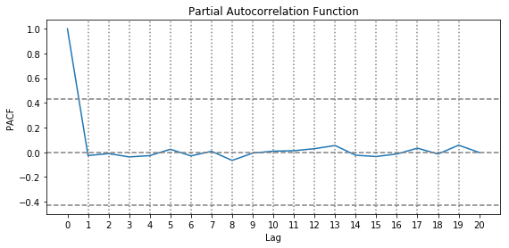

```
Figure 5: Plotting for Partial Autocorrelation shows that it converges to 0 at lag = 1
```

```python
pacf_stock_plot = pacf(diff, nlags=20)
#Plot ACF:
plt.figure(figsize=(20, 4))

plt.subplot(121)
plt.plot(pacf_stock_plot)
plt.xticks(np.arange(21))
plt.axhline(y=0,linestyle='--',color='gray')
plt.axhline(y=-1.96/np.sqrt(len(pacf_stock_plot)),linestyle='--',color='gray')
plt.axhline(y=1.96/np.sqrt(len(pacf_stock_plot)),linestyle='--',color='gray')
for i in range(1,20):
    plt.axvline(x=i,linestyle=':',color='gray')
plt.title('Partial Autocorrelation Function');
plt.xlabel('Lag')
plt.ylabel('PACF')
plt.show();
print("Figure 5: Plotting for Partial Autocorrelation shows that it converges to 0 at lag = 1")
```

### Manual ARIMA Selection based on ACF and PACF (1, 0, 1)

The statistics for a (1, 0, 1) ARIMA model based on the stationary difference in price shift shows that both 0.7461 for first-order AR and -0.7775 for first-order MA are significant with a p value of 0.0001 and less than 0.0001, respectively [Figure 6]. Both AR1 of 1.3402 and MA1 of 1.2862 are on the real number line. The residual kernel density graph has a single peak at 0.025877 and suggests a good fit for the model [Figure 6].

| Model: | ARMA | BIC: | 1709.4949 |
| --- | --- | --- | --- |
| Dependent Variable: | close | Log-Likelihood: | -840.88 |
| Date: | 2018-06-03 20:41 | Scale: | 1.0000 |
| No. Observations: | 1028 | Method: | css-mle |
| Df Model: | 3 | Sample: | 01-03-2014 |
| Df Residuals: | 1025 |  | 02-01-2018 |
| Converged: | 1.0000 | S.D. of innovations: | 0.548 |
| AIC: | 1689.7534 | HQIC: | 1697.247 |

|  | Coef. | Std.Err. | t | P>\|t\| | [0.025 | 0.975] |
| --- | --- | --- | --- | --- | --- | --- |
| const | 0.0147 | 0.0150 | 0.9779 | 0.3284 | -0.0147 | 0.0441 |
| ar.L1.close | 0.7461 | 0.1893 | 3.9415 | 0.0001 | 0.3751 | 1.1172 |
| ma.L1.close | -0.7775 | 0.1782 | -4.3621 | 0.0000 | -1.1268 | -0.4281 |

|  | Real | Imaginary | Modulus | Frequency |
| --- | --- | --- | --- | --- |
| AR.1 | 1.3402 | 0.0000 | 1.3402 | 0.0000 |
| MA.1 | 1.2862 | 0.0000 | 1.2862 | 0.0000 |

|  | Residuals |
| --- | --- |
| count | 1028.000000 |
| mean | -0.000021 |
| std | 0.548548 |
| min | -3.115282 |
| 25% | -0.274917 |
| 50% | 0.025877 |
| 75% | 0.298516 |
| max | 3.244779 |

```
Figure 6: Summary statistics for (1, 0, 1) ARIMA model and plotting for residuals and kernel density
```

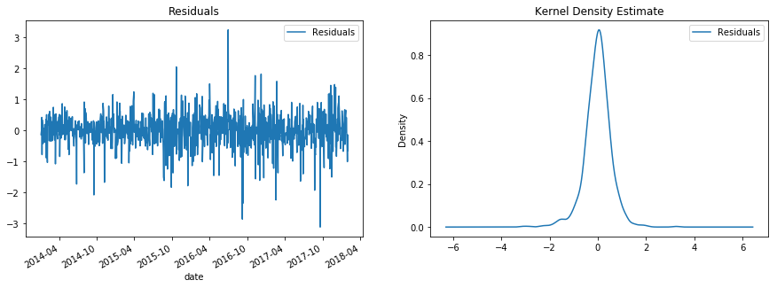

```python
model = ARIMA(diff, order=(1, 0, 1))
model_fit = model.fit(disp=-1)
display(model_fit.summary2())
# plot residual errors
residuals = pd.DataFrame(model_fit.resid, columns=['Residuals'])
f, ax = plt.subplots(nrows=1, ncols=2,figsize=(15, 5))
residuals.plot(title='Residuals',ax=ax[0])
residuals.plot(kind='kde', title='Kernel Density Estimate',ax=ax[1])
display(residuals.describe())
print("Figure 6: Summary statistics for (1, 0, 1) ARIMA model and plotting for residuals and kernel density")
```

### Plot Manual ARIMA Predictions (1, 0, 1) Against Stock Price

The differencing in price shift could then be accumulated and added to the initial value of the stock price in 1/1/14 to recreate the ARIMA prediction model to be plotted against the stock price [5] [Figure 7]. Because the ARIMA model is created from the stationary price difference model, the prediction values for future stock prices has a large confidence interval, which could deviate away from the actual price as time increases and does not compensate for outside interference [3][7].

```python
predictions_ARIMA_diff_cumsum = model_fit.fittedvalues.cumsum()
predictions_ARIMA = pd.Series(price.ix[0], index=price.index)
predictions_ARIMA = predictions_ARIMA.add(predictions_ARIMA_diff_cumsum,fill_value=0)
```

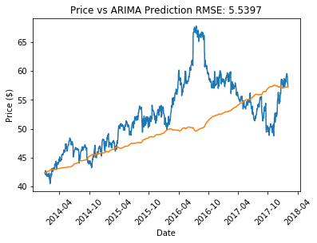

```
Figure 7: Plotting ARIMA model (1, 0, 1) against stock price
```

```python
plt.plot(price);
plt.plot(predictions_ARIMA);
plt.title('Price vs ARIMA Prediction RMSE: %.4f'% np.sqrt(sum((predictions_ARIMA-price)**2)/len(price)));
plt.xlabel('Date')
plt.xticks(rotation='45')
plt.ylabel('Price ($)')
plt.show();
print("Figure 7: Plotting ARIMA model (1, 0, 1) against stock price")
```

### Grid Search for the Best Parameters

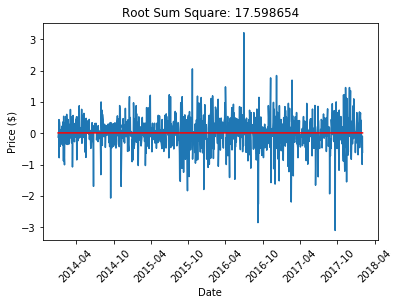

```
p: 0 , d: 0 , q: 0 , Root Sum Square: 17.598654
```

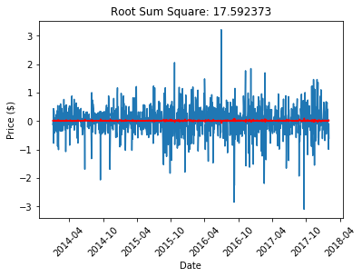

```
p: 0 , d: 0 , q: 1 , Root Sum Square: 17.592373
```

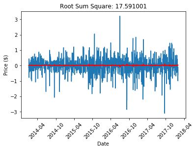

```
p: 0 , d: 0 , q: 2 , Root Sum Square: 17.591001
```

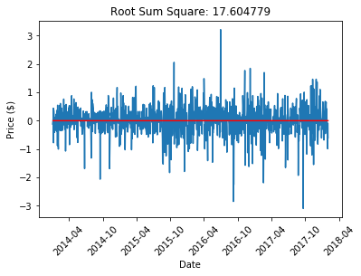

```
p: 0 , d: 1 , q: 0 , Root Sum Square: 17.604779
```

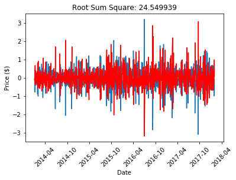

```
p: 0 , d: 1 , q: 1 , Root Sum Square: 24.549939
```

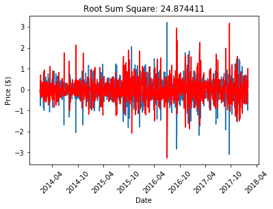

```
p: 0 , d: 1 , q: 2 , Root Sum Square: 24.874411
```

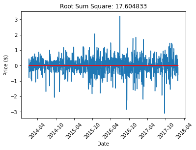

```
p: 0 , d: 2 , q: 0 , Root Sum Square: 17.604833
```

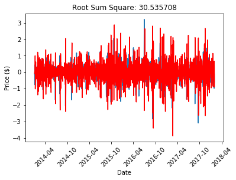

```
p: 0 , d: 2 , q: 1 , Root Sum Square: 30.535708
```

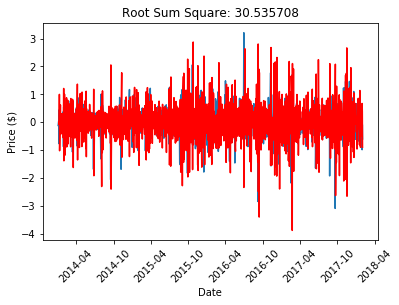

```
p: 0 , d: 2 , q: 2 , Root Sum Square: 30.535708
```

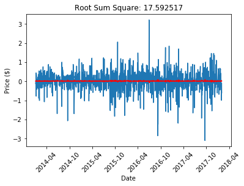

```
p: 1 , d: 0 , q: 0 , Root Sum Square: 17.592517
```

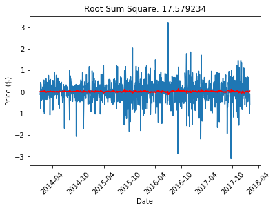

```
p: 1 , d: 0 , q: 1 , Root Sum Square: 17.579234
```

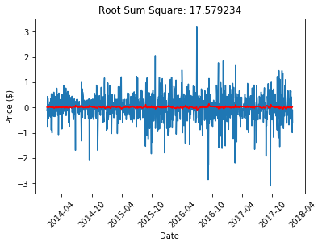

```
p: 1 , d: 0 , q: 2 , Root Sum Square: 17.579234
```

[15 more figures not shown]

```
p: 3 , d: 1 , q: 2 , Root Sum Square: 24.836419
```

```
p: 3 , d: 2 , q: 0 , Root Sum Square: 39.298325
```

```
p: 3 , d: 2 , q: 1 , Root Sum Square: 39.298325
```

```
p: 3 , d: 2 , q: 2 , Root Sum Square: 39.298325
Figure 8 to 44: Grid search for best ARIMA model
```

```python
loss_best = 1E16
best_ints = [-1,-1,-1]
losses = []
for p in range(4):
    for d in range(3):
        for q in range(3):
            model = ARIMA(diff, order=(p, d, q))
            try:
                results_ARIMA = model.fit(disp=-1)
            except ValueError:
                pass
            except:
                pass
            plt.plot(diff)
            plt.plot(results_ARIMA.fittedvalues, color='red')
            x=pd.DataFrame(results_ARIMA.fittedvalues)
            x=x.join(diff)
            x['out']=(x.iloc[:,0]-x.iloc[:,1])**2
            loss=np.sqrt(x['out'].sum())
            plt.title('Root Sum Square: %.6f'% loss)
            plt.xlabel('Date')
            plt.xticks(rotation='45')
            plt.ylabel('Price ($)')
            plt.show();
            if loss < loss_best:
                loss_best = loss
                best_ints=[p,d,q]
            losses.append({'q':q,'p':p,'d':d,'loss':loss})
            plt.show()
            print('p:', p,', d:', d,', q:', q,', Root Sum Square: %.6f'% loss)
losses=pd.DataFrame(losses).sort_values('loss').reset_index()
print("Figure 8 to 44: Grid search for best ARIMA model")
```

### Best Parameters Based on Root Sum Square

After running though the grid search, the best p, d, and q parameters for the General Mills stock is (3, 0, 2), where the root sum square is minimized at 17.524942.

```python
print('Best Root Sum Square: %.6f'% loss_best)
print('Best p, d, q: ', best_ints)
```

```
Best Root Sum Square: 17.524942
Best p, d, q:  [3, 0, 2]
```

### Top 10 ARIMA Parameters Ordered by Least Root Sum Square

Upon further scrutiny of the dictionary, the manual selection of the (1, 0, 1) model based on ACF and PACF is ranked 7th based on smallest RSS value [Table 1].

```python
print("Table 1: Top 10 ARIMA parameters ordered by least root sum square")
display(losses[['p','d','q','loss']].iloc[:10])
```

```
Table 1: Top 10 ARIMA parameters ordered by least root sum square
```

|  | p | d | q | loss |
| --- | --- | --- | --- | --- |
| 0 | 3 | 0 | 2 | 17.524942 |
| 1 | 3 | 0 | 1 | 17.574523 |
| 2 | 2 | 0 | 2 | 17.579047 |
| 3 | 2 | 0 | 1 | 17.579047 |
| 4 | 3 | 0 | 0 | 17.579127 |
| 5 | 1 | 0 | 2 | 17.579234 |
| 6 | 1 | 0 | 1 | 17.579234 |
| 7 | 0 | 0 | 2 | 17.591001 |
| 8 | 2 | 0 | 0 | 17.591488 |
| 9 | 0 | 0 | 1 | 17.592373 |

### Difference in Root Sum Square Loss Between (3, 0, 2) and (1, 0, 1)

However, the difference in root sum square between (3, 0, 2) and (1, 0, 1) models is negligible with a loss increase of 0.054292 between the first and seventh model over the course of 4 years of stock data.

```python
print('Difference between (3, 0, 2) and (1, 0, 1):', losses[['loss']].iloc[6]-losses[['loss']].iloc[0])
```

```
Difference between (3, 0, 2) and (1, 0, 1): loss    0.054292
dtype: float64
```

### Best Parameters Based on Grid Search (3, 0, 2)

| Model: | ARMA | BIC: | 1724.1448 |
| --- | --- | --- | --- |
| Dependent Variable: | close | Log-Likelihood: | -837.80 |
| Date: | 2018-06-03 20:42 | Scale: | 1.0000 |
| No. Observations: | 1028 | Method: | css-mle |
| Df Model: | 6 | Sample: | 01-03-2014 |
| Df Residuals: | 1022 |  | 02-01-2018 |
| Converged: | 0.0000 | S.D. of innovations: | 0.547 |
| AIC: | 1689.5972 | HQIC: | 1702.710 |

|  | Coef. | Std.Err. | t | P>\|t\| | [0.025 | 0.975] |
| --- | --- | --- | --- | --- | --- | --- |
| const | 0.0146 | 0.0166 | 0.8744 | 0.3821 | -0.0181 | 0.0472 |
| ar.L1.close | -1.1771 | 0.0412 | -28.5821 | 0.0000 | -1.2578 | -1.0964 |
| ar.L2.close | -1.0008 | 0.0483 | -20.7156 | 0.0000 | -1.0954 | -0.9061 |
| ar.L3.close | -0.0363 | 0.0329 | -1.1015 | 0.2710 | -0.1008 | 0.0283 |
| ma.L1.close | 1.1554 | 0.0274 | 42.1600 | 0.0000 | 1.1017 | 1.2091 |
| ma.L2.close | 0.9833 | 0.0171 | 57.6503 | 0.0000 | 0.9499 | 1.0167 |

|  | Real | Imaginary | Modulus | Frequency |
| --- | --- | --- | --- | --- |
| AR.1 | -0.5948 | -0.8309 | 1.0219 | -0.3489 |
| AR.2 | -0.5948 | 0.8309 | 1.0219 | 0.3489 |
| AR.3 | -26.3956 | -0.0000 | 26.3956 | -0.5000 |
| MA.1 | -0.5875 | -0.8197 | 1.0085 | -0.3490 |
| MA.2 | -0.5875 | 0.8197 | 1.0085 | 0.3490 |

|  | Residuals |
| --- | --- |
| count | 1028.000000 |
| mean | -0.000024 |
| std | 0.546854 |
| min | -3.125061 |
| 25% | -0.266697 |
| 50% | 0.020948 |
| 75% | 0.299240 |
| max | 3.217457 |

```
Figure 45: Summary statistics for (3, 0, 2) ARIMA model and plotting for residuals and kernel density
```

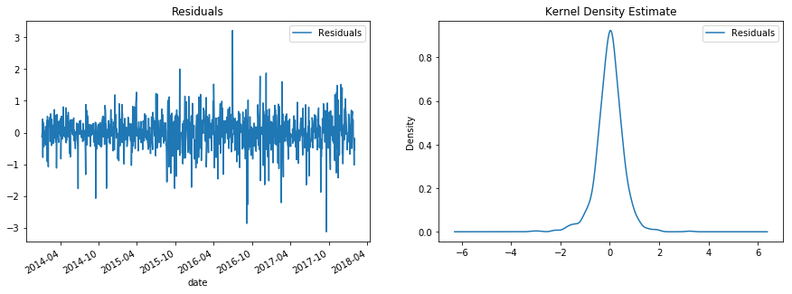

```python
model = ARIMA(diff, order=(3, 0, 2))
model_fit = model.fit(disp=-1)
display(model_fit.summary2())
# plot residual errors
residuals = pd.DataFrame(model_fit.resid, columns=['Residuals'])
f, ax = plt.subplots(nrows=1, ncols=2,figsize=(15, 5))
residuals.plot(title='Residuals',ax=ax[0])
residuals.plot(kind='kde', title='Kernel Density Estimate',ax=ax[1])
display(residuals.describe())
print("Figure 45: Summary statistics for (3, 0, 2) ARIMA model and plotting for residuals and kernel density")
```

### Plot Grid Search ARIMA Predictions (3, 0, 2) Against Stock Price

The differencing in price shift could then be accumulated and added to the initial value of the stock price in 1/1/14 to recreate the ARIMA prediction model to be plotted against the stock price [5] [Figure 46]. Because the ARIMA model is created from the stationary price difference model, the prediction values for future stock prices has a large confidence interval, which could deviate away from the actual price as time increases and does not compensate for outside interference [3][7]. The reduction of root mean square from 5.54 to 5.02 over the course of 4 years of stock data is also negligible between the (1, 0, 1) and (3, 0, 2) ARIMA models [Figure 7][Figure 46].

```python
predictions_ARIMA_diff_cumsum = model_fit.fittedvalues.cumsum()
predictions_ARIMA = pd.Series(price.ix[0], index=price.index)
predictions_ARIMA = predictions_ARIMA.add(predictions_ARIMA_diff_cumsum,fill_value=0)
```

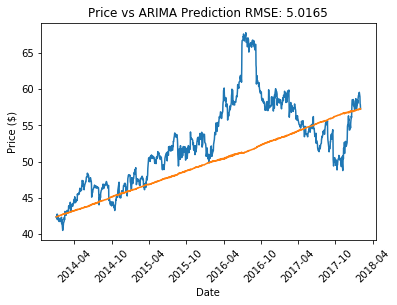

```
Figure 46: Plotting ARIMA model (3, 0, 2) against stock price
```

```python
plt.plot(price);
plt.plot(predictions_ARIMA);
plt.title('Price vs ARIMA Prediction RMSE: %.4f'% np.sqrt(sum((predictions_ARIMA-price)**2)/len(price)));
plt.xlabel('Date')
plt.xticks(rotation='45')
plt.ylabel('Price ($)')
plt.show();
print("Figure 46: Plotting ARIMA model (3, 0, 2) against stock price")
```

## Conclusion

### Final Decision on Best Parameters via Occam's Razor: Manual Selection Based on ACF and PACF Convergence (1, 0, 1)

Due to the negligible difference in root mean square and root sum square between the grid search model (3, 0, 2) and the manual ACF and PACF plotted model (1, 0, 1), Occam's Razor is applied, where the simpler model that uses less assumptions is the optimal model because it is less likely to over-fit the data [2]. Therefore, the optimal model that overall fits the 4-year General Mills stock prices is ARIMA model (1, 0, 1).

To reiterate, the statistics for a (1, 0, 1) ARIMA model based on the stationary difference in price shift shows that both 0.7461 for first-order AR and -0.7775 for first-order MA are significant with a p value of 0.0001 and less than 0.0001, respectively [Figure 47]. Both AR1 of 1.3402 and MA1 of 1.2862 are on the real number line. The residual kernel density graph has a single peak at 0.025877 and suggests a good fit for the model [Figure 47].

| Model: | ARMA | BIC: | 1709.4949 |
| --- | --- | --- | --- |
| Dependent Variable: | close | Log-Likelihood: | -840.88 |
| Date: | 2018-06-03 20:42 | Scale: | 1.0000 |
| No. Observations: | 1028 | Method: | css-mle |
| Df Model: | 3 | Sample: | 01-03-2014 |
| Df Residuals: | 1025 |  | 02-01-2018 |
| Converged: | 1.0000 | S.D. of innovations: | 0.548 |
| AIC: | 1689.7534 | HQIC: | 1697.247 |

|  | Coef. | Std.Err. | t | P>\|t\| | [0.025 | 0.975] |
| --- | --- | --- | --- | --- | --- | --- |
| const | 0.0147 | 0.0150 | 0.9779 | 0.3284 | -0.0147 | 0.0441 |
| ar.L1.close | 0.7461 | 0.1893 | 3.9415 | 0.0001 | 0.3751 | 1.1172 |
| ma.L1.close | -0.7775 | 0.1782 | -4.3621 | 0.0000 | -1.1268 | -0.4281 |

|  | Real | Imaginary | Modulus | Frequency |
| --- | --- | --- | --- | --- |
| AR.1 | 1.3402 | 0.0000 | 1.3402 | 0.0000 |
| MA.1 | 1.2862 | 0.0000 | 1.2862 | 0.0000 |

|  | Residuals |
| --- | --- |
| count | 1028.000000 |
| mean | -0.000021 |
| std | 0.548548 |
| min | -3.115282 |
| 25% | -0.274917 |
| 50% | 0.025877 |
| 75% | 0.298516 |
| max | 3.244779 |

```
Figure 47: Summary statistics for (1, 0, 1) ARIMA model and plotting for residuals and kernel density
```

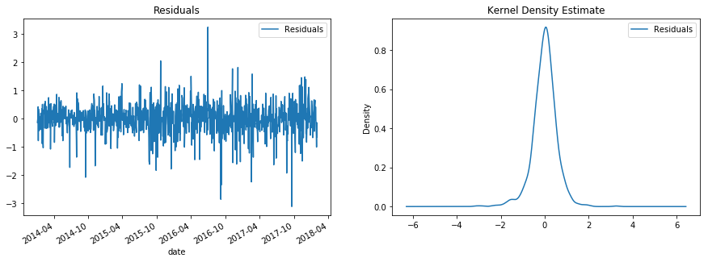

```python
model = ARIMA(diff, order=(1, 0, 1))
model_fit = model.fit(disp=-1)
display(model_fit.summary2())
# plot residual errors
residuals = pd.DataFrame(model_fit.resid, columns=['Residuals'])
f, ax = plt.subplots(nrows=1, ncols=2,figsize=(15, 5))
residuals.plot(title='Residuals',ax=ax[0])
residuals.plot(kind='kde', title='Kernel Density Estimate',ax=ax[1])
display(residuals.describe())
print("Figure 47: Summary statistics for (1, 0, 1) ARIMA model and plotting for residuals and kernel density")
```

### Plot the ARIMA Predictions of the Best Parameters (1, 0, 1) Against Price

To reiterate, the differencing in price shift could then be accumulated and added to the initial value of the stock price in 1/1/14 to recreate the ARIMA prediction model to be plotted against the stock price [5] [Figure 48]. Because the ARIMA model is created from the stationary price difference model, the prediction values for future stock prices has a large confidence interval, which could deviate away from the actual price as time increases and does not compensate for outside interference [3][7].

Therefore, using the same Python platform, Long-Short Term Memory (LSTM) Neural Networks or other Deep Learning Neural Networks with the consideration on seasonality could be implemented as a future study on multiple stock prices and general stock market indexes for new levels of market trend study and prediction accuracy [8][9].

```python
predictions_ARIMA_diff_cumsum = model_fit.fittedvalues.cumsum()
predictions_ARIMA = pd.Series(price.ix[0], index=price.index)
predictions_ARIMA = predictions_ARIMA.add(predictions_ARIMA_diff_cumsum,fill_value=0)
```

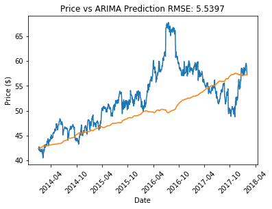

```
Figure 48: Plotting ARIMA model (1, 0, 1) against stock price
```

```python
plt.plot(price);
plt.plot(predictions_ARIMA);
plt.title('Price vs ARIMA Prediction RMSE: %.4f'% np.sqrt(sum((predictions_ARIMA-price)**2)/len(price)));
plt.xlabel('Date')
plt.xticks(rotation='45')
plt.ylabel('Price ($)')
plt.show();
print("Figure 48: Plotting ARIMA model (1, 0, 1) against stock price")
```

## Citations

1. J. Hur, "History of The Stock Market," BeBusinessEd, 05-Sep-2017. [Online]. Available: https://bebusinessed.com/history/history-of-the-stock-market/. [Accessed: 3-Jun-2018].
2. V. Balasubramanian, "Statistical Inference & Occam’s Razor," UPenn, [Online]. 2012. Available: https://www.sas.upenn.edu/~vbalasub/public-html/Inference.html. [Accessed: 3-Jun-2018].
3. R. Nau, "Introduction to ARIMA: nonseasonal models," Duke U, [Online]. 2004. Available: https://people.duke.edu/~rnau/411arim.htm [Accessed: 3-Jun-2018].
4. N. Gondo. "4 Top Income Stocks With Steady, Rising Dividends," Investor's Business Daily, [Online]. 2015. Available: https://www.investors.com/research/the-income-investor/stocks-steady-rising-dividends/ [Accessed: 3-Jun-2018].
5. A. Jain. "A comprehensive beginner’s guide to create a Time Series Forecast (with Codes in Python)," Analytics Vidhya, [Online]. 2016. Available: https://www.analyticsvidhya.com/blog/2016/02/time-series-forecasting-codes-python/ [Accessed: 3-Jun-2018].
6. R. Slater. "ARIMAS-improved," 2DS SMU, [Python Notebook]. 2018. Class Attachment Download. [Accessed: 29-May-2018].
7. "Forecasting Stock Returns using ARIMA model," R-Bloggers, [Online]. 2017. Available: https://www.r-bloggers.com/forecasting-stock-returns-using-arima-model/ [Accessed: 3-Jun-2018].
8. "Time series prediction using ARIMA vs LSTM," Data Science Stack Exchange, [Online]. 2017. Available: https://datascience.stackexchange.com/questions/12721/time-series-prediction-using-arima-vs-lstm [Accessed: 3-Jun-2018].
9. A. Adebiyi. "Comparison of ARIMA and Artificial Neural Networks Models for Stock Price Prediction," Journal of Applied Mathematics, [Online]. 2014. Available: https://www.hindawi.com/journals/jam/2014/614342/ [Accessed: 3-Jun-2018].